# Predicción de Retornos Financieros con Machine Learning

## Importar librerias necesarias

#### En este proyecto se utilizan las siguientes librerías fundamentales de Python para el análisis de datos y Machine Learning:

- pandas: manipulación y análisis de datos tabulares.
- numpy: operaciones matemáticas y manejo de arreglos multidimensionales.
- matplotlib y seaborn: visualización de datos (gráficos estadísticos y exploratorios).

```python
import pandas as pd
import seaborn as sns
import matplotlib.pyplot as plt
import numpy as np
##
# Estas librerías constituyen la base para la exploración, limpieza y análisis de los datos financieros que se utilizarán a lo largo del proyecto.
##
```

## Cargar el dataset

Para este análisis se utiliza el dataset S&P 500 Daily Update, correspondiente al sector financiero, que contiene información de precios de mercado bursátil. El dataset fue obtenido desde Kaggle y está en formato Excel (data_Snp.xlsx). El primer paso es cargar los datos en un DataFrame de pandas, al que llamaremos data. Esto nos permitirá trabajar sobre una copia en memoria sin alterar el archivo original.

```python
data = pd.read_excel("data_Snp.xlsx")
```

## Inspección inicial del dataset

Inspección inicial del dataset

El primer paso tras cargar los datos es realizar una exploración básica del dataset para entender su estructura, el tipo de variables disponibles y la calidad de la información. Esto nos permite identificar rápidamente posibles problemas de calidad (valores nulos, duplicados, inconsistencias) y también confirmar que los datos cargados corresponden a lo esperado.

- data.shape : dimensiones del dataset (número de filas y columnas).
- data.head() : primeras 5 filas para observar la estructura inicial.
- data.tail() : últimas 5 filas para verificar consistencia.
- data.nunique() : número de valores únicos por columna (útil para categóricas).
- data.isnull().sum() : cantidad de valores nulos por columna.
- data.info() : tipos de datos, conteo de valores no nulos y memoria usada.
- data.describe() : estadísticas descriptivas de las variables numéricas (media, mediana, cuartiles, mínimos, máximos, desviación estándar).

```python
## =========================
# Visualización inicial del data
## =========================
data
```

|  | Date | A | AAPL | ABBV | ABNB | ABT | ACGL | ACN | ADBE | ADI | ... | WY.4 | WYNN.4 | XEL.4 | XOM.4 | XYL.4 | XYZ.4 | YUM.4 | ZBH.4 | ZBRA.4 | ZTS.4 |
| --- | --- | --- | --- | --- | --- | --- | --- | --- | --- | --- | --- | --- | --- | --- | --- | --- | --- | --- | --- | --- | --- |
| 0 | 2010-01-04 | 19.931623 | 6.424606 | NaN | NaN | 18.496675 | 7.601905 | 31.492170 | 37.090000 | 22.062073 | ... | 1832400 | 4741400 | 2670400 | 27809100 | NaN | NaN | 2962274 | 805872 | 168800 | NaN |
| 1 | 2010-01-05 | 19.715111 | 6.435713 | NaN | NaN | 18.347231 | 7.576549 | 31.686798 | 37.700001 | 22.027245 | ... | 1724500 | 5644300 | 4321400 | 30174700 | NaN | NaN | 3298757 | 1769643 | 168800 | NaN |
| 2 | 2010-01-06 | 19.645065 | 6.333344 | NaN | NaN | 18.449120 | 7.543795 | 32.023666 | 37.619999 | 21.985445 | ... | 2254400 | 2738800 | 2164500 | 35044700 | NaN | NaN | 4178981 | 1315619 | 385300 | NaN |
| 3 | 2010-01-07 | 19.619593 | 6.321634 | NaN | NaN | 18.601959 | 7.499420 | 31.993713 | 36.889999 | 21.811289 | ... | 1420700 | 2388500 | 3041700 | 27192100 | NaN | NaN | 2452472 | 1734005 | 183600 | NaN |
| 4 | 2010-01-08 | 19.613220 | 6.363664 | NaN | NaN | 18.697056 | 7.484628 | 31.866451 | 36.689999 | 21.936689 | ... | 1310000 | 1539800 | 1599100 | 24891800 | NaN | NaN | 3772392 | 2213985 | 266500 | NaN |
| ... | ... | ... | ... | ... | ... | ... | ... | ... | ... | ... | ... | ... | ... | ... | ... | ... | ... | ... | ... | ... | ... |
| 3925 | 2025-08-12 | 117.320000 | 229.649994 | 198.639999 | 121.610001 | 131.020004 | 87.779999 | 237.869995 | 338.429993 | 232.039993 | ... | 3432400 | 1515400 | 3136900 | 14109400 | 867700.0 | 7048000.0 | 1606700 | 1913100 | 628400 | 2578500.0 |
| 3926 | 2025-08-13 | 120.290001 | 233.330002 | 201.470001 | 124.550003 | 129.399994 | 89.949997 | 245.679993 | 351.070007 | 237.630005 | ... | 4369200 | 1539400 | 3227000 | 17958700 | 1833300.0 | 8084300.0 | 1845000 | 1254300 | 539200 | 3331100.0 |
| 3927 | 2025-08-14 | 118.870003 | 232.779999 | 204.679993 | 124.639999 | 129.279999 | 91.459999 | 246.160004 | 348.579987 | 236.210007 | ... | 3300900 | 1605800 | 2703000 | 13683500 | 779100.0 | 6560300.0 | 1832900 | 1525100 | 604800 | 2565100.0 |
| 3928 | 2025-08-15 | 119.199997 | 231.589996 | 206.690002 | 125.099998 | 131.750000 | 90.720001 | 247.009995 | 354.850006 | 231.630005 | ... | 4414200 | 1497000 | 7793300 | 19271900 | 765100.0 | 6691800.0 | 2604300 | 1058200 | 523900 | 3705700.0 |
| 3929 | 2025-08-18 | 118.150002 | 230.889999 | 206.570007 | 125.489998 | 130.270004 | 90.349998 | 249.130005 | 357.239990 | 231.550003 | ... | 3207100 | 2721300 | 3113000 | 13034200 | 859500.0 | 6778000.0 | 2182800 | 1141800 | 360200 | 2158500.0 |

3930 rows × 2516 columns

```python
## =========================
# Dimensiones del data
## =========================
data.shape
```

```
(3930, 2516)
```

```python
## =========================
# Visualización de datos unicos
## =========================
data
data.nunique()
```

```
Date      3930
A         3739
AAPL      3877
ABBV      3079
ABNB      1100
          ...
XYZ.4     2425
YUM.4     3791
ZBH.4     3669
ZBRA.4    2951
ZTS.4     3009
Length: 2516, dtype: int64
```

```python
## =========================
# Tipos de datos
## =========================
data
data.info()
```

```
<class 'pandas.core.frame.DataFrame'>
RangeIndex: 3930 entries, 0 to 3929
Columns: 2516 entries, Date to ZTS.4
dtypes: datetime64[ns](1), float64(2089), int64(426)
memory usage: 75.4 MB
```

```python
## =========================
# Estadisticas descriptivas
## =========================
data
data.describe()
```

|  | Date | A | AAPL | ABBV | ABNB | ABT | ACGL | ACN | ADBE | ADI | ... | WY.4 | WYNN.4 | XEL.4 | XOM.4 | XYL.4 | XYZ.4 | YUM.4 | ZBH.4 | ZBRA.4 | ZTS.4 |
| --- | --- | --- | --- | --- | --- | --- | --- | --- | --- | --- | --- | --- | --- | --- | --- | --- | --- | --- | --- | --- | --- |
| count | 3930 | 3930.000000 | 3930.000000 | 3176.000000 | 1176.000000 | 3930.000000 | 3930.000000 | 3930.000000 | 3930.000000 | 3930.000000 | ... | 3.930000e+03 | 3.930000e+03 | 3.930000e+03 | 3.930000e+03 | 3.481000e+03 | 2.449000e+03 | 3.930000e+03 | 3.930000e+03 | 3.930000e+03 | 3.155000e+03 |
| mean | 2017-10-23 06:14:50.381679616 | 70.788753 | 73.247339 | 83.506942 | 138.775200 | 61.349017 | 34.394448 | 156.320068 | 233.941226 | 91.608301 | ... | 4.339084e+06 | 2.680687e+06 | 3.148647e+06 | 1.746538e+07 | 1.166512e+06 | 1.047134e+07 | 3.360371e+06 | 1.489059e+06 | 3.884148e+05 | 2.822254e+06 |
| min | 2010-01-04 00:00:00 | 17.174309 | 5.765364 | 20.204023 | 82.489998 | 15.821719 | 7.346220 | 27.517172 | 22.690001 | 18.460535 | ... | 7.096000e+05 | 2.895000e+05 | 0.000000e+00 | 3.851300e+06 | 1.846000e+05 | 3.185000e+05 | 3.404000e+05 | 2.405050e+05 | 3.180000e+04 | 4.174000e+05 |
| 25% | 2013-11-26 06:00:00 | 33.194329 | 17.955994 | 42.288616 | 120.795002 | 29.797560 | 17.333296 | 64.111229 | 56.280002 | 37.824419 | ... | 2.965350e+06 | 1.580350e+06 | 2.201350e+06 | 1.132010e+07 | 7.625000e+05 | 5.865200e+06 | 1.617025e+06 | 9.793498e+05 | 2.165500e+05 | 1.708500e+06 |
| 50% | 2017-10-21 12:00:00 | 60.235006 | 37.119556 | 68.035633 | 136.814995 | 47.738073 | 27.271770 | 123.014046 | 170.010002 | 73.660782 | ... | 3.842500e+06 | 2.186450e+06 | 2.820750e+06 | 1.508500e+07 | 1.015300e+06 | 8.796800e+06 | 2.496186e+06 | 1.290442e+06 | 3.224500e+05 | 2.306100e+06 |
| 75% | 2021-09-16 18:00:00 | 116.690266 | 138.376488 | 127.173624 | 153.355000 | 99.853722 | 40.477374 | 263.013863 | 401.857498 | 147.823494 | ... | 5.075325e+06 | 3.139000e+06 | 3.653300e+06 | 2.084802e+07 | 1.382800e+06 | 1.297540e+07 | 4.348233e+06 | 1.747395e+06 | 4.646000e+05 | 3.265400e+06 |
| max | 2025-08-18 00:00:00 | 174.417160 | 258.103729 | 212.837784 | 216.839996 | 138.949753 | 109.220207 | 394.312805 | 688.369995 | 245.679993 | ... | 5.759470e+07 | 2.608880e+07 | 2.282710e+07 | 1.180235e+08 | 2.024170e+07 | 1.403139e+08 | 5.110631e+07 | 1.276634e+07 | 1.157870e+07 | 6.678910e+07 |
| std | NaN | 44.106270 | 70.444005 | 49.767006 | 24.687670 | 36.758062 | 25.041462 | 105.697779 | 193.966365 | 62.970757 | ... | 2.383753e+06 | 1.904361e+06 | 1.550862e+06 | 9.128544e+06 | 7.735575e+05 | 8.066322e+06 | 2.755498e+06 | 8.329628e+05 | 3.479090e+05 | 2.450316e+06 |

8 rows × 2516 columns

```python
## =========================
# Visualización inicial de las primeras 10 filas
## =========================
data
data.head(10)
```

|  | Date | A | AAPL | ABBV | ABNB | ABT | ACGL | ACN | ADBE | ADI | ... | WY.4 | WYNN.4 | XEL.4 | XOM.4 | XYL.4 | XYZ.4 | YUM.4 | ZBH.4 | ZBRA.4 | ZTS.4 |
| --- | --- | --- | --- | --- | --- | --- | --- | --- | --- | --- | --- | --- | --- | --- | --- | --- | --- | --- | --- | --- | --- |
| 0 | 2010-01-04 | 19.931623 | 6.424606 | NaN | NaN | 18.496675 | 7.601905 | 31.492170 | 37.090000 | 22.062073 | ... | 1832400 | 4741400 | 2670400 | 27809100 | NaN | NaN | 2962274 | 805872 | 168800 | NaN |
| 1 | 2010-01-05 | 19.715111 | 6.435713 | NaN | NaN | 18.347231 | 7.576549 | 31.686798 | 37.700001 | 22.027245 | ... | 1724500 | 5644300 | 4321400 | 30174700 | NaN | NaN | 3298757 | 1769643 | 168800 | NaN |
| 2 | 2010-01-06 | 19.645065 | 6.333344 | NaN | NaN | 18.449120 | 7.543795 | 32.023666 | 37.619999 | 21.985445 | ... | 2254400 | 2738800 | 2164500 | 35044700 | NaN | NaN | 4178981 | 1315619 | 385300 | NaN |
| 3 | 2010-01-07 | 19.619593 | 6.321634 | NaN | NaN | 18.601959 | 7.499420 | 31.993713 | 36.889999 | 21.811289 | ... | 1420700 | 2388500 | 3041700 | 27192100 | NaN | NaN | 2452472 | 1734005 | 183600 | NaN |
| 4 | 2010-01-08 | 19.613220 | 6.363664 | NaN | NaN | 18.697056 | 7.484628 | 31.866451 | 36.689999 | 21.936689 | ... | 1310000 | 1539800 | 1599100 | 24891800 | NaN | NaN | 3772392 | 2213985 | 266500 | NaN |
| 5 | 2010-01-11 | 19.625961 | 6.307526 | NaN | NaN | 18.792154 | 7.461384 | 31.836510 | 36.209999 | 21.811289 | ... | 1116800 | 1909000 | 2266600 | 30685000 | NaN | NaN | 5790177 | 1468780 | 104100 | NaN |
| 6 | 2010-01-12 | 19.390343 | 6.235778 | NaN | NaN | 18.737816 | 7.482515 | 31.634407 | 35.660000 | 20.905680 | ... | 907600 | 3306500 | 3481400 | 31496700 | NaN | NaN | 6634514 | 1520486 | 120400 | NaN |
| 7 | 2010-01-13 | 19.543177 | 6.323737 | NaN | NaN | 18.915714 | 7.522664 | 31.993713 | 36.279999 | 20.898708 | ... | 727100 | 2959300 | 3438400 | 24884400 | NaN | NaN | 5638001 | 789392 | 155900 | NaN |
| 8 | 2010-01-14 | 19.836102 | 6.287113 | NaN | NaN | 18.936245 | 7.512098 | 32.278164 | 35.900002 | 20.877817 | ... | 780300 | 4431900 | 2278400 | 18630800 | NaN | NaN | 4147962 | 777959 | 119000 | NaN |
| 9 | 2010-01-15 | 19.377613 | 6.182044 | NaN | NaN | 18.984133 | 7.498364 | 32.046112 | 35.869999 | 20.174223 | ... | 1341000 | 2742300 | 3249700 | 29411900 | NaN | NaN | 6315975 | 1474445 | 107200 | NaN |

10 rows × 2516 columns

```python
## =========================
# Visualización inicial de las ultimas filas
## =========================
data.tail(10)
```

|  | Date | A | AAPL | ABBV | ABNB | ABT | ACGL | ACN | ADBE | ADI | ... | WY.4 | WYNN.4 | XEL.4 | XOM.4 | XYL.4 | XYZ.4 | YUM.4 | ZBH.4 | ZBRA.4 | ZTS.4 |
| --- | --- | --- | --- | --- | --- | --- | --- | --- | --- | --- | --- | --- | --- | --- | --- | --- | --- | --- | --- | --- | --- |
| 3920 | 2025-08-05 | 114.889999 | 202.689957 | 198.550003 | 129.960007 | 130.690002 | 88.660004 | 247.070007 | 338.739990 | 220.679993 | ... | 4830600 | 2255500 | 4542700 | 21314300 | 1082400.0 | 7207400.0 | 5141600 | 1875600 | 2001700 | 7335300.0 |
| 3921 | 2025-08-06 | 113.230003 | 213.008255 | 196.300003 | 130.500000 | 130.929993 | 89.760002 | 247.539993 | 345.619995 | 220.690002 | ... | 3767800 | 949800 | 2863300 | 15321800 | 956600.0 | 6488700.0 | 2685300 | 2094600 | 1127500 | 4987500.0 |
| 3922 | 2025-08-07 | 113.980003 | 219.780563 | 198.860001 | 120.029999 | 132.059998 | 88.860001 | 241.720001 | 338.269989 | 223.119995 | ... | 3248300 | 2025800 | 3601900 | 13468300 | 938200.0 | 14968800.0 | 2066800 | 4223600 | 786100 | 3786700.0 |
| 3923 | 2025-08-08 | 114.620003 | 229.090012 | 198.050003 | 121.019997 | 134.279999 | 88.830002 | 239.199997 | 341.049988 | 223.949997 | ... | 2407100 | 4212600 | 3328900 | 14417700 | 597000.0 | 22800800.0 | 2263200 | 2459700 | 612500 | 2062100.0 |
| 3924 | 2025-08-11 | 114.129997 | 227.179993 | 198.639999 | 118.300003 | 131.360001 | 89.879997 | 238.610001 | 333.649994 | 224.070007 | ... | 3034300 | 1917100 | 2480800 | 13570700 | 957700.0 | 10172000.0 | 1825000 | 1839900 | 535600 | 3065300.0 |
| 3925 | 2025-08-12 | 117.320000 | 229.649994 | 198.639999 | 121.610001 | 131.020004 | 87.779999 | 237.869995 | 338.429993 | 232.039993 | ... | 3432400 | 1515400 | 3136900 | 14109400 | 867700.0 | 7048000.0 | 1606700 | 1913100 | 628400 | 2578500.0 |
| 3926 | 2025-08-13 | 120.290001 | 233.330002 | 201.470001 | 124.550003 | 129.399994 | 89.949997 | 245.679993 | 351.070007 | 237.630005 | ... | 4369200 | 1539400 | 3227000 | 17958700 | 1833300.0 | 8084300.0 | 1845000 | 1254300 | 539200 | 3331100.0 |
| 3927 | 2025-08-14 | 118.870003 | 232.779999 | 204.679993 | 124.639999 | 129.279999 | 91.459999 | 246.160004 | 348.579987 | 236.210007 | ... | 3300900 | 1605800 | 2703000 | 13683500 | 779100.0 | 6560300.0 | 1832900 | 1525100 | 604800 | 2565100.0 |
| 3928 | 2025-08-15 | 119.199997 | 231.589996 | 206.690002 | 125.099998 | 131.750000 | 90.720001 | 247.009995 | 354.850006 | 231.630005 | ... | 4414200 | 1497000 | 7793300 | 19271900 | 765100.0 | 6691800.0 | 2604300 | 1058200 | 523900 | 3705700.0 |
| 3929 | 2025-08-18 | 118.150002 | 230.889999 | 206.570007 | 125.489998 | 130.270004 | 90.349998 | 249.130005 | 357.239990 | 231.550003 | ... | 3207100 | 2721300 | 3113000 | 13034200 | 859500.0 | 6778000.0 | 2182800 | 1141800 | 360200 | 2158500.0 |

10 rows × 2516 columns

## Preprocesamiento

Para este ejercicio se seleccionó la acción de Abbott Laboratories (ticker: ABT) dentro del índice S&P 500. La elección se realiza únicamente con fines académicos, ya que se trata de una empresa del sector salud con datos históricos consistentes y de interés para análisis de inversión.

Se filtra el dataset para trabajar únicamente con dos columnas relevantes:

- Date : fecha de la observación.
- ABT : precio ajustado de la acción de Abbott.

```python
## =========================
# Filtramos el dataset para ABT
## =========================
abt = data[["Date","ABT"]].copy()
## =========================
# Visualizamos las primeras 15 filas
## =========================
abt.head(15)
```

|  | Date | ABT |
| --- | --- | --- |
| 0 | 2010-01-04 | 18.496675 |
| 1 | 2010-01-05 | 18.347231 |
| 2 | 2010-01-06 | 18.449120 |
| 3 | 2010-01-07 | 18.601959 |
| 4 | 2010-01-08 | 18.697056 |
| 5 | 2010-01-11 | 18.792154 |
| 6 | 2010-01-12 | 18.737816 |
| 7 | 2010-01-13 | 18.915714 |
| 8 | 2010-01-14 | 18.936245 |
| 9 | 2010-01-15 | 18.984133 |
| 10 | 2010-01-19 | 19.227039 |
| 11 | 2010-01-20 | 19.240730 |
| 12 | 2010-01-21 | 19.008087 |
| 13 | 2010-01-22 | 18.648861 |
| 14 | 2010-01-25 | 18.713865 |

#### Transformación de fecha

Un paso esencial en el análisis de series temporales es asegurarse de que la columna de fechas esté en el formato adecuado (datetime) y en orden cronológico. Esto facilita la creación de gráficos de evolución y el entrenamiento de modelos que dependen de la secuencia temporal.

```python
# ==============================
# Transformar "Date" a datetime
# ==============================
abt["Date"] = pd.to_datetime(abt["Date"])

# Ordenar cronológicamente y resetear el índice
abt = abt.sort_values("Date")
abt = abt.reset_index(drop=True)

# Confirmamos la transformación
abt
```

|  | Date | ABT |
| --- | --- | --- |
| 0 | 2010-01-04 | 18.496675 |
| 1 | 2010-01-05 | 18.347231 |
| 2 | 2010-01-06 | 18.449120 |
| 3 | 2010-01-07 | 18.601959 |
| 4 | 2010-01-08 | 18.697056 |
| ... | ... | ... |
| 3925 | 2025-08-12 | 131.020004 |
| 3926 | 2025-08-13 | 129.399994 |
| 3927 | 2025-08-14 | 129.279999 |
| 3928 | 2025-08-15 | 131.750000 |
| 3929 | 2025-08-18 | 130.270004 |

3930 rows × 2 columns

## Creación de nuevas características

En el análisis de series temporales, una práctica esencial es generar variables derivadas que ayuden a los modelos a capturar patrones históricos y a identificar tendencias en los precios. Para este proyecto se construyeron dos tipos principales de variables: rezagos (lags) y medias móviles (SMA/EMA).

#### Objetivo: Los rezagos representan valores pasados del precio, desplazados cierto número de días. Estas variables permiten a los modelos aprender la dependencia temporal, ya que el precio de un día está influenciado por los valores previos.

```python
# Crear rezagos de 1, 5, 15, 25, 30, 60 y 90 días
abt["lag_1"] = abt["ABT"].shift(1)
abt["lag_5"] = abt["ABT"].shift(5)
abt["lag_15"] = abt["ABT"].shift(15)
abt["lag_25"] = abt["ABT"].shift(25)
abt["lag_30"] = abt["ABT"].shift(30)
abt["lag_60"] = abt["ABT"].shift(60)
abt["lag_90"] = abt["ABT"].shift(90)
##
# Los rezagos capturan el "efecto memoria" de la serie, muy útil para algoritmos de regresión y modelos no lineales.
##
```

#### Creación de medias móviles

#### Objetivo: Las medias móviles suavizan el comportamiento de la serie, reduciendo el ruido y permitiendo identificar la tendencia subyacente. Se construyeron tanto medias móviles simples (SMA) como una exponencial (EMA):

- SMA (Simple Moving Average): promedios de los últimos 10, 20, 30, 50 y 200 días.
- EMA (Exponential Moving Average): media móvil ponderada, que otorga mayor importancia a los datos recientes.

```python
# Media móvil exponencial (EMA)
abt["EMA_20"] = abt["ABT"].ewm(span=20, adjust=False).mean()

# Medias móviles simples (SMA)
abt["SMA_10"]  = abt["ABT"].rolling(window=10).mean().shift(1)
abt["SMA_20"]  = abt["ABT"].rolling(window=20).mean().shift(1)
abt["SMA_30"]  = abt["ABT"].rolling(window=30).mean().shift(1)
abt["SMA_50"]  = abt["ABT"].rolling(window=50).mean().shift(1)
abt["SMA_200"] = abt["ABT"].rolling(window=200).mean().shift(1)
##
# Las medias móviles son indicadores técnicos ampliamente usados en finanzas, ya que ayudan a detectar puntos de entrada/salida y tendencias alcistas o bajistas.
##
```

#### Creación de indicadores financieros

Además de los precios, es necesario generar indicadores que reflejen la dinámica del activo, su nivel de riesgo y las tendencias que siguen los inversores. Para este análisis se construyeron tres tipos de variables adicionales: retornos, volatilidad y momentum.

```python
## =================
# Retornos
## =================
abt["retorno_diario"] = abt["ABT"].pct_change().shift(1)
abt["retorno_5d"] = abt["ABT"].pct_change(5).shift(1)
abt["retorno_20d"] = abt["ABT"].pct_change(20).shift(1)
abt["retorno_30d"] = abt["ABT"].pct_change(30).shift(1)
abt["retorno_200d"] = abt["ABT"].pct_change(200).shift(1)

## =========================
# iterpretación:
## =========================
# * retorno_diario: indica cuánto subió o bajó la acción en un día.
# * retorno_5d (o mayor): mide la variación acumulada en intervalos más largos, lo cual ayuda a detectar tendencias de mediano y largo plazo.
```

```python
## =================
# Volatilidad
## =================
# La volatilidad mide la variabilidad de los retornos en un periodo de tiempo y es utilizada como indicador de riesgo en los mercados financieros.
# Se calculó la desviación estándar de los retornos en una ventana móvil de 20 días:

# Volatilidad (desviación estándar de los retornos en ventana de 20 días)

abt["volatilidad_20"] = abt["retorno_diario"].rolling(window=20).std().shift(1)

## =================
# Momentum
## =================
# El momentum evalúa la fuerza de la tendencia comparando el precio actual con el de varios días atrás.
# Este indicador se usa comúnmente para determinar si una acción mantiene un impulso alcista o bajista.

abt["momentum_10"] = (abt["ABT"] / abt["ABT"].shift(10) - 1).shift(1)
```

## Creación de indicadores técnicos

Además de los rezagos, medias móviles y retornos, se incorporaron indicadores técnicos ampliamente utilizados en el análisis de mercados financieros. Estos indicadores proporcionan señales de tendencia, volatilidad y fortaleza del mercado, útiles tanto para inversores como para modelos predictivos.

#### Bandas de Bollinger

Las Bandas de Bollinger permiten medir la volatilidad alrededor de una media móvil.

- BB_medio: media móvil de 20 días.
- BB_sup: dos desviaciones estándar por encima de la media (zona de sobrecompra).
- BB_inf: dos desviaciones estándar por debajo (zona de sobreventa).

```python
abt["BB_medio"] = abt["ABT"].rolling(window=20).mean().shift(1)
abt["BB_sup"] = (abt["BB_medio"] + 2*abt["ABT"].rolling(window=20).std()).shift(1)
abt["BB_inf"] = (abt["BB_medio"] - 2*abt["ABT"].rolling(window=20).std()).shift(1)
##
# Este indicador combina tendencia y volatilidad, mostrando cuándo el precio se aleja demasiado de su media.
##
```

##### RSI (Relative Strength Index)

El RSI mide la velocidad y el cambio de los movimientos de precio para identificar si un activo está sobrecomprado (>70) o sobrevendido (<30).

```python
delta = abt["ABT"].diff()
gain = (delta.where(delta > 0, 0)).rolling(14).mean()
loss = (-delta.where(delta < 0, 0)).rolling(14).mean()
rs = gain / loss
abt["RSI_14"] = (100 - (100 / (1 + rs))).shift(1)
```

##### MACD (Moving Average Convergence Divergence)

El MACD es un indicador de tendencia que compara dos medias móviles exponenciales (12 y 26 días) y genera una señal al cruzarse con una tercera (9 días).

```python
ema12 = abt["ABT"].ewm(span=12, adjust=False).mean()
ema26 = abt["ABT"].ewm(span=26, adjust=False).mean()

abt["MACD"] = (ema12 - ema26).shift(1)
abt["Signal"] = abt["MACD"].ewm(span=9, adjust=False).mean().shift(1)

##
# El cruce entre MACD y Signal se interpreta como confirmación de una tendencia alcista o bajista.
##
```

#### Definición de la variable objetivo

Para entrenar los modelos de Machine Learning se define como variable objetivo el retorno a 20 días. Esto permite que los modelos aprendan a predecir la variación futura del precio de Abbott, en lugar del valor absoluto del precio.

```python
abt["target_retorno_20d"] = abt["ABT"].pct_change(20).shift(-20)
## Con este diseño, el objetivo del modelo es anticipar si la acción de Abbott generará un retorno positivo o negativo en el horizonte de 20 días.
```

#### Visualización del dataset final con nuevas variables

Tras la creación de todas las variables derivadas (rezagos, medias móviles, retornos, volatilidad, indicadores técnicos), el dataset abt contiene ahora múltiples columnas listas para el modelado:

```python
## ==============================
# Visualización de las primeras filas con todas las columnas
## ==============================
abt.head(20)

# Este paso permite verificar que todas las variables fueron generadas correctamente y que están alineadas con el índice temporal.
```

|  | Date | ABT | lag_1 | lag_5 | lag_15 | lag_25 | lag_30 | lag_60 | lag_90 | EMA_20 | ... | retorno_200d | volatilidad_20 | momentum_10 | BB_medio | BB_sup | BB_inf | RSI_14 | MACD | Signal | target_retorno_20d |
| --- | --- | --- | --- | --- | --- | --- | --- | --- | --- | --- | --- | --- | --- | --- | --- | --- | --- | --- | --- | --- | --- |
| 0 | 2010-01-04 | 18.496675 | NaN | NaN | NaN | NaN | NaN | NaN | NaN | 18.496675 | ... | NaN | NaN | NaN | NaN | NaN | NaN | NaN | NaN | NaN | 0.006933 |
| 1 | 2010-01-05 | 18.347231 | 18.496675 | NaN | NaN | NaN | NaN | NaN | NaN | 18.482443 | ... | NaN | NaN | NaN | NaN | NaN | NaN | NaN | 0.000000 | NaN | 0.019051 |
| 2 | 2010-01-06 | 18.449120 | 18.347231 | NaN | NaN | NaN | NaN | NaN | NaN | 18.479269 | ... | NaN | NaN | NaN | NaN | NaN | NaN | NaN | -0.011922 | 0.000000 | -0.001969 |
| 3 | 2010-01-07 | 18.601959 | 18.449120 | NaN | NaN | NaN | NaN | NaN | NaN | 18.490954 | ... | NaN | NaN | NaN | NaN | NaN | NaN | NaN | -0.012998 | -0.002384 | -0.007410 |
| 4 | 2010-01-08 | 18.697056 | 18.601959 | NaN | NaN | NaN | NaN | NaN | NaN | 18.510583 | ... | NaN | NaN | NaN | NaN | NaN | NaN | NaN | -0.001501 | -0.004507 | -0.023803 |
| 5 | 2010-01-11 | 18.792154 | 18.697056 | 18.496675 | NaN | NaN | NaN | NaN | NaN | 18.537399 | ... | NaN | NaN | NaN | NaN | NaN | NaN | NaN | 0.015110 | -0.003906 | -0.028743 |
| 6 | 2010-01-12 | 18.737816 | 18.792154 | 18.347231 | NaN | NaN | NaN | NaN | NaN | 18.556486 | ... | NaN | NaN | NaN | NaN | NaN | NaN | NaN | 0.035538 | -0.000103 | -0.027570 |
| 7 | 2010-01-13 | 18.915714 | 18.737816 | 18.449120 | NaN | NaN | NaN | NaN | NaN | 18.590698 | ... | NaN | NaN | NaN | NaN | NaN | NaN | NaN | 0.046803 | 0.007025 | -0.031651 |
| 8 | 2010-01-14 | 18.936245 | 18.915714 | 18.601959 | NaN | NaN | NaN | NaN | NaN | 18.623608 | ... | NaN | NaN | NaN | NaN | NaN | NaN | NaN | 0.069287 | 0.014981 | -0.025655 |
| 9 | 2010-01-15 | 18.984133 | 18.936245 | 18.697056 | NaN | NaN | NaN | NaN | NaN | 18.657943 | ... | NaN | NaN | NaN | NaN | NaN | NaN | NaN | 0.087751 | 0.025842 | -0.016219 |
| 10 | 2010-01-19 | 19.227039 | 18.984133 | 18.792154 | NaN | NaN | NaN | NaN | NaN | 18.712143 | ... | NaN | NaN | NaN | NaN | NaN | NaN | NaN | 0.105037 | 0.038224 | -0.025801 |
| 11 | 2010-01-20 | 19.240730 | 19.227039 | 18.737816 | NaN | NaN | NaN | NaN | NaN | 18.762485 | ... | NaN | NaN | 0.039486 | NaN | NaN | NaN | NaN | 0.136761 | 0.051587 | -0.022582 |
| 12 | 2010-01-21 | 19.008087 | 19.240730 | 18.915714 | NaN | NaN | NaN | NaN | NaN | 18.785875 | ... | NaN | NaN | 0.048699 | NaN | NaN | NaN | NaN | 0.161149 | 0.068622 | -0.021238 |
| 13 | 2010-01-22 | 18.648861 | 19.008087 | 18.936245 | NaN | NaN | NaN | NaN | NaN | 18.772826 | ... | NaN | NaN | 0.030298 | NaN | NaN | NaN | NaN | 0.159862 | 0.087127 | -0.002018 |
| 14 | 2010-01-25 | 18.713865 | 18.648861 | 18.984133 | NaN | NaN | NaN | NaN | NaN | 18.767211 | ... | NaN | NaN | 0.002521 | NaN | NaN | NaN | 54.364390 | 0.128375 | 0.101674 | -0.013346 |
| 15 | 2010-01-26 | 18.638601 | 18.713865 | 19.227039 | 18.496675 | NaN | NaN | NaN | NaN | 18.754962 | ... | NaN | NaN | 0.000899 | NaN | NaN | NaN | 56.004712 | 0.107429 | 0.107014 | -0.002753 |
| 16 | 2010-01-27 | 18.440172 | 18.638601 | 19.240730 | 18.347231 | NaN | NaN | NaN | NaN | 18.724982 | ... | NaN | NaN | -0.008171 | NaN | NaN | NaN | 58.400163 | 0.083789 | 0.107097 | 0.004082 |
| 17 | 2010-01-28 | 18.457273 | 18.440172 | 19.008087 | 18.449120 | NaN | NaN | NaN | NaN | 18.699486 | ... | NaN | NaN | -0.015885 | NaN | NaN | NaN | 49.755650 | 0.048485 | 0.102436 | 0.006117 |
| 18 | 2010-01-29 | 18.111732 | 18.457273 | 18.648861 | 18.601959 | NaN | NaN | NaN | NaN | 18.643510 | ... | NaN | NaN | -0.024236 | NaN | NaN | NaN | 45.732276 | 0.021636 | 0.091645 | 0.025501 |
| 19 | 2010-02-01 | 18.248585 | 18.111732 | 18.713865 | 18.697056 | NaN | NaN | NaN | NaN | 18.605898 | ... | NaN | NaN | -0.043541 | NaN | NaN | NaN | 34.957462 | -0.027211 | 0.077643 | 0.023247 |

20 rows × 29 columns

##### Eliminación de valores nulos (NaN)

La creación de nuevas características basadas en ventanas de tiempo (rolling, shift, etc.) genera automáticamente valores nulos en los primeros registros, ya que no existen suficientes datos previos para calcularlos. Para evitar problemas en el entrenamiento de los modelos, se eliminan todas las filas que contienen al menos un valor nulo:

```python
# Eliminar todas las filas con al menos un NaN
abt = abt.dropna()

# Confirmar que ya no hay valores faltantes
abt.head(20)

##
# Este procedimiento asegura que todos los registros utilizados por los modelos estén completos y que no haya inconsistencias en las variables predictoras.
##
```

|  | Date | ABT | lag_1 | lag_5 | lag_15 | lag_25 | lag_30 | lag_60 | lag_90 | EMA_20 | ... | retorno_200d | volatilidad_20 | momentum_10 | BB_medio | BB_sup | BB_inf | RSI_14 | MACD | Signal | target_retorno_20d |
| --- | --- | --- | --- | --- | --- | --- | --- | --- | --- | --- | --- | --- | --- | --- | --- | --- | --- | --- | --- | --- | --- |
| 201 | 2010-10-20 | 18.404198 | 18.562187 | 18.671030 | 18.277241 | 17.988234 | 17.566902 | 17.156019 | 16.328861 | 18.400116 | ... | 0.003542 | 0.005749 | 0.004302 | 18.383547 | 18.835994 | 17.890766 | 59.854173 | 0.229146 | 0.224026 | -0.088135 |
| 202 | 2010-10-21 | 18.551661 | 18.404198 | 18.681551 | 18.190193 | 17.970816 | 17.789755 | 17.138607 | 16.618666 | 18.414548 | ... | 0.003105 | 0.006815 | -0.002367 | 18.398600 | 18.837360 | 17.929735 | 57.054669 | 0.201837 | 0.225050 | -0.098789 |
| 203 | 2010-10-22 | 18.453346 | 18.551661 | 18.667509 | 18.308571 | 17.981258 | 17.946447 | 17.055048 | 16.832567 | 18.418243 | ... | 0.005558 | 0.007094 | 0.013277 | 18.427816 | 18.808635 | 17.988566 | 57.862689 | 0.189904 | 0.220407 | -0.098174 |
| 204 | 2010-10-25 | 18.435793 | 18.453346 | 18.843058 | 18.284199 | 18.197149 | 17.915104 | 17.089859 | 16.777365 | 18.419915 | ... | -0.007989 | 0.006981 | 0.003517 | 18.446198 | 18.804919 | 18.050714 | 55.221294 | 0.170548 | 0.214307 | -0.100171 |
| 205 | 2010-10-26 | 18.498991 | 18.435793 | 18.562187 | 18.482674 | 18.158850 | 17.901178 | 17.351011 | 16.825665 | 18.427446 | ... | -0.013973 | 0.007042 | 0.002563 | 18.460915 | 18.795143 | 18.097252 | 48.370912 | 0.152039 | 0.205555 | -0.108939 |
| 206 | 2010-10-27 | 18.130341 | 18.498991 | 18.404198 | 18.447859 | 18.103134 | 17.988234 | 17.410206 | 16.663517 | 18.399150 | ... | -0.015600 | 0.007037 | -0.007160 | 18.473918 | 18.794056 | 18.127774 | 51.742454 | 0.140847 | 0.194852 | -0.090627 |
| 207 | 2010-10-28 | 18.168966 | 18.130341 | 18.551661 | 18.308571 | 17.967339 | 17.970816 | 17.472881 | 16.556557 | 18.377228 | ... | -0.032420 | 0.006985 | -0.028959 | 18.466573 | 18.830939 | 18.116897 | 44.747457 | 0.101065 | 0.184051 | -0.095652 |
| 208 | 2010-10-29 | 18.017992 | 18.168966 | 18.453346 | 18.388668 | 18.085726 | 17.981258 | 17.403244 | 16.408215 | 18.343015 | ... | -0.039478 | 0.008359 | -0.027438 | 18.465512 | 18.827162 | 18.105985 | 43.363038 | 0.071826 | 0.167454 | -0.094115 |
| 209 | 2010-11-01 | 17.765213 | 18.017992 | 18.435793 | 18.388668 | 18.141436 | 18.197149 | 17.608688 | 16.373720 | 18.287986 | ... | -0.048492 | 0.008310 | -0.034794 | 18.450983 | 18.873081 | 18.057942 | 39.738289 | 0.036056 | 0.148328 | -0.080830 |
| 210 | 2010-11-02 | 17.863514 | 17.765213 | 18.498991 | 18.632397 | 18.238935 | 18.158850 | 17.716621 | 16.280556 | 18.247560 | ... | -0.064207 | 0.008358 | -0.057201 | 18.425034 | 18.957370 | 17.944596 | 26.112783 | -0.012544 | 0.125874 | -0.076061 |
| 211 | 2010-11-03 | 17.919689 | 17.863514 | 18.130341 | 18.671030 | 18.277241 | 18.103134 | 17.922060 | 16.277115 | 18.216334 | ... | -0.070917 | 0.008869 | -0.037640 | 18.394076 | 18.989013 | 17.861054 | 28.464288 | -0.042637 | 0.098190 | -0.067202 |
| 212 | 2010-11-04 | 17.863514 | 17.919689 | 18.168966 | 18.681551 | 18.190193 | 17.967339 | 17.546013 | 16.094261 | 18.182732 | ... | -0.068659 | 0.008557 | -0.026326 | 18.367667 | 18.995661 | 17.792490 | 30.164855 | -0.061247 | 0.070025 | -0.068986 |
| 213 | 2010-11-05 | 17.877560 | 17.863514 | 18.017992 | 18.667509 | 18.308571 | 18.085726 | 17.546013 | 16.139112 | 18.153668 | ... | -0.060215 | 0.008624 | -0.037094 | 18.345414 | 19.010002 | 17.725332 | 29.517278 | -0.079610 | 0.043770 | -0.078555 |
| 214 | 2010-11-08 | 17.712549 | 17.877560 | 17.765213 | 18.843058 | 18.284199 | 18.141436 | 17.431101 | 16.028713 | 18.111657 | ... | -0.041359 | 0.008514 | -0.031202 | 18.319859 | 19.020345 | 17.670483 | 23.197215 | -0.091970 | 0.019094 | -0.070565 |
| 215 | 2010-11-09 | 17.572113 | 17.712549 | 17.863514 | 18.562187 | 18.482674 | 18.238935 | 17.528593 | 16.028713 | 18.060272 | ... | -0.053507 | 0.008428 | -0.039230 | 18.286053 | 19.046062 | 17.593656 | 24.792006 | -0.113769 | -0.003119 | -0.066334 |
| 216 | 2010-11-10 | 17.614235 | 17.572113 | 17.919689 | 18.404198 | 18.447859 | 18.277241 | 17.650469 | 16.108059 | 18.017792 | ... | -0.057219 | 0.008600 | -0.050104 | 18.233039 | 19.059093 | 17.513013 | 25.052953 | -0.140754 | -0.025249 | -0.060594 |
| 217 | 2010-11-11 | 17.477316 | 17.614235 | 17.863514 | 18.551661 | 18.308571 | 18.190193 | 17.490297 | 16.459969 | 17.966318 | ... | -0.044790 | 0.007921 | -0.028466 | 18.180199 | 19.024280 | 17.441797 | 19.999707 | -0.156932 | -0.048350 | -0.043391 |
| 218 | 2010-11-12 | 17.056004 | 17.477316 | 17.877560 | 18.453346 | 18.388668 | 18.308571 | 17.173433 | 16.594521 | 17.879622 | ... | -0.053093 | 0.007932 | -0.038068 | 18.119987 | 18.993765 | 17.366632 | 19.517446 | -0.178741 | -0.070066 | -0.022643 |
| 219 | 2010-11-15 | 16.908546 | 17.056004 | 17.712549 | 18.435793 | 18.388668 | 18.284199 | 17.180397 | 16.570370 | 17.787138 | ... | -0.058290 | 0.007961 | -0.053390 | 18.039412 | 19.019860 | 17.220114 | 15.586559 | -0.227400 | -0.091801 | -0.002284 |
| 220 | 2010-11-16 | 16.733002 | 16.908546 | 17.572113 | 18.498991 | 18.632397 | 18.482674 | 17.333607 | 16.497917 | 17.686744 | ... | -0.073432 | 0.009186 | -0.048222 | 17.942686 | 18.990014 | 17.088810 | 11.932573 | -0.274694 | -0.118921 | 0.009652 |

20 rows × 29 columns

```python
## =========================
# Verificación del dataset final
## =========================
abt.info()
```

```
<class 'pandas.core.frame.DataFrame'>
Index: 3709 entries, 201 to 3909
Data columns (total 29 columns):
 #   Column              Non-Null Count  Dtype
---  ------              --------------  -----
 0   Date                3709 non-null   datetime64[ns]
 1   ABT                 3709 non-null   float64
 2   lag_1               3709 non-null   float64
 3   lag_5               3709 non-null   float64
 4   lag_15              3709 non-null   float64
 5   lag_25              3709 non-null   float64
 6   lag_30              3709 non-null   float64
 7   lag_60              3709 non-null   float64
 8   lag_90              3709 non-null   float64
 9   EMA_20              3709 non-null   float64
```

[output cut: 21 more lines]

#### Detencion de Valores nulos

Antes de entrenar los modelos es importante verificar la calidad de los datos y asegurarse de que no existan valores faltantes.

```python
# Identificar columnas con valores nulos
col_con_nulos = abt.columns[abt.isnull().any()]
col_con_nulos
```

```
Index([], dtype='object')
```

```python
# Contar el número de nulos por columna
total_nulos_col = abt[col_con_nulos].isnull().sum()
total_nulos_col
```

```
Series([], dtype: float64)
```

```python
# Calcular porcentaje de nulos en el dataset
porcentaje_nulos = abt.isnull().median() * 100
porcentaje_nulos
```

```
Date                  0.0
ABT                   0.0
lag_1                 0.0
lag_5                 0.0
lag_15                0.0
lag_25                0.0
lag_30                0.0
lag_60                0.0
lag_90                0.0
EMA_20                0.0
SMA_10                0.0
SMA_20                0.0
SMA_30                0.0
SMA_50                0.0
SMA_200               0.0
retorno_diario        0.0
retorno_5d            0.0
retorno_20d           0.0
retorno_30d           0.0
retorno_200d          0.0
volatilidad_20        0.0
momentum_10           0.0
BB_medio              0.0
BB_sup                0.0
BB_inf                0.0
RSI_14                0.0
MACD                  0.0
Signal                0.0
target_retorno_20d    0.0
dtype: float64
```

```python
## =========================
# Resultados
## =========================
# No se detectaron columnas con valores nulos (Index([], dtype='object')).
# El conteo de valores faltantes es cero en todas las columnas.
# El pocentaje de nulos es 0% en todas las variables.
```

## Visualizaciones Exploratorias (EDA)

#### Graficos de Distribuciones y detección de outliers

Un paso fundamental en el análisis exploratorio es evaluar cómo se distribuyen las variables y si existen valores atípicos (outliers) que puedan afectar el desempeño de los modelos. Para esto se creó una función que, para cualquier variable seleccionada:

- Genera un histograma con curva de densidad para visualizar la distribución de los valores.
- Genera un boxplot para detectar valores extremos.

```python
# Creamos una funcion para graficar Distribucion de los datos y un Boxplot para detectar posibles Outliers

def graficos_1(df,col):
    plt.figure(figsize=(17,8))
    # Grafico de distribucion
    plt.subplot(1,2,1)
    sns.histplot(df[col], kde=True)
    plt.title(f"Distribuccion de la variable {col}")
    plt.xlabel(f"{col}")
    plt.ylabel("Frecuencia")
    plt.grid()

    # Grafico boxplot para deteccion de outliers
    plt.subplot(1,2,2)
    sns.boxplot(x=df[col])
    plt.title(f"Boxplot de la variable {col} para detenccion de Outliers")
    plt.xlabel(f"{col}")
    plt.tight_layout()
    plt.show()
```

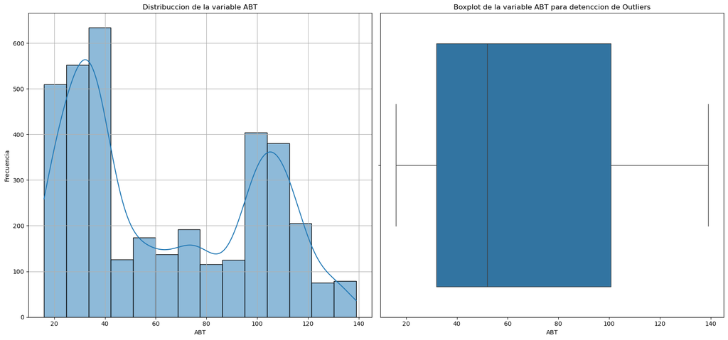

```
Curtosis: -1.4018144324765898
Sesgo: 0.34447548986319915
```

```python
# Aplicamos la funcion creada anteriormente
graficos_1(abt,"ABT")

# Kurtosis
kur = abt["ABT"].kurt()
kur # Curtosis con un valor de -1.4041419490658114
print(f"Curtosis: {kur}")

# Skew
sesgo = abt["ABT"].skew()
sesgo # 0.33987852019923925
print(f"Sesgo: {sesgo}")

## ==================================
# Análisis de distribución de la variable ABT
## ==================================
## Se generaron dos gráficos principales para analizar la variable ABT (precio ajustado de Abbott):
# * Histograma con curva de densidad (KDE) : permite observar cómo se distribuyen los precios.
# * Boxplot : facilita la detección de posibles valores atípicos.

## Resultados observados:
# * El histograma muestra una distribución asimétrica a la derecha, con mayor concentración de precios en rangos bajos (entre 20 y 60 USD), pero con presencia de valores más altos (hasta 140 USD).
# * El boxplot confirma que no existen outliers extremos significativos, ya que los precios se mantienen dentro de los límites de las bandas del gráfico.

# * Kurtosis = -1.40 : distribución platicúrtica, con colas más ligeras que la distribución normal. Esto significa que hay menos valores extremos de lo esperado.
# * Sesgo (Skew) = 0.33 : distribución con ligero sesgo positivo, es decir, la mayoría de los precios se concentran en valores bajos, pero existen algunos precios relativamente más altos que alargan la cola hacia la derecha.
```

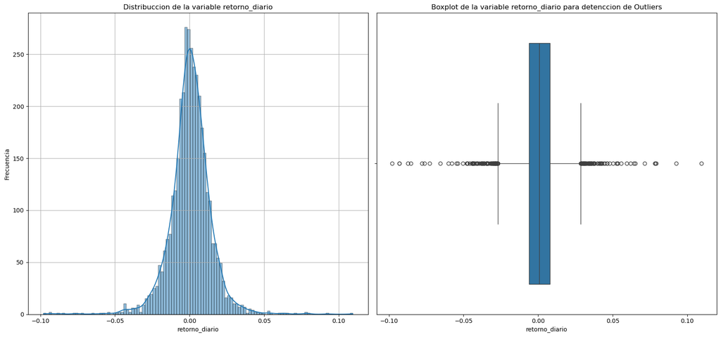

```
Curtosis: 7.006187249335511
Sesgo: -0.1951634366760626
```

```python
graficos_1(abt,"retorno_diario")
# Kurtosis
kur = abt["retorno_diario"].kurt()
kur # 6.992968614161424
print(f"Curtosis: {kur}")
#
# Skew
sesgo = abt["retorno_diario"].skew()
sesgo # -0.19681772696453598
print(f"Sesgo: {sesgo}")

## ==================================
# Análisis de distribución de la variable "retorno_diario"
## ==================================

#* El histograma refleja una distribución con forma de campana, centrada en 0.
#* El boxplot muestra outliers frecuentes, tanto positivos como negativos, lo cual es típico en datos financieros por la volatilidad de los mercados.

#* Kurtosis = 6.99 : distribución leptocúrtica, con colas mucho más pesadas que una distribución normal.
#* Implica que existen eventos extremos (grandes variaciones diarias), aunque poco frecuentes.
#* Sesgo (Skew) = -0.19 : ligera asimetría negativa, lo que sugiere que los retornos negativos (pérdidas) tienden a ser un poco más frecuentes o pronunciados que los positivos.

#* Los retornos diarios no siguen una distribución normal, sino que presentan colas largas y outliers frecuentes, lo cual es consistente con la naturaleza de las series financieras.
#* Este comportamiento debe considerarse al momento de modelar, ya que algunos algoritmos lineales pueden verse afectados por la presencia de valores extremos.
#* La ligera asimetría negativa sugiere un sesgo hacia caídas más abruptas que los aumentos, lo cual es común en mercados financieros.
```